# Introdução

# Fatores Acadêmicos:

**1) Quantos estudantes avaliam seu desempenho acadêmico como abaixo da média?** **2) Quantos estudantes têm preocupações sobre suas futuras carreiras?**

```python
#1) Quantos estudantes avaliam seu desempenho acadêmico como abaixo da média?
len(df.loc[df['academic_performance'] < df.academic_performance.mean()])
print("{} estudantes apresentaram desempenho acadêmico abaixo da media".format(len(df.loc[df['academic_performance'] < df.academic_performance.mean()])))
```

```
561 estudantes apresentaram desempenho acadêmico abaixo da media
```

```python
#2) Quantos estudantes têm preocupações sobre suas futuras carreiras?
df.groupby('future_career_concerns')['future_career_concerns'].count()
```

```
future_career_concerns
0     30
1    327
2    199
3    173
4    185
5    186
Name: future_career_concerns, dtype: int64
```

```python
#2) Quantos estudantes têm preocupações sobre suas futuras carreiras?
df['career_concern'] = np.where(df['future_career_concerns'] >= 4, "Yes", "No")
```

```python
#2) Quantos estudantes têm preocupações sobre suas futuras carreiras?
print("{} estudantes apresentaram nível de preocupação acima de 4 em um range de 0 a 5".format(len(df.query('career_concern == "Yes"'))))
```

```
371 estudantes apresentaram nível de preocupação acima de 4 em um range de 0 a 5
```

# Fatores sociais:

**1) Quantos estudantes sentem que têm um forte apoio social?** **2) Qual a porcentagem de alunos que sofreram bullying?** **3) Quantos alunos participam de atividades extracurriculares?**

```python
#1) Quantos estudantes sentem que têm um forte apoio social?
df.groupby('social_support')['social_support'].count()
```

```
social_support
0     88
1    412
2    142
3    458
Name: social_support, dtype: int64
```

```python
#1) Quantos estudantes sentem que têm um forte apoio social?
df['support_class'] = np.where(df['social_support'] == 3, 'Strong', np.where(df['social_support'] == 2, 'Ok', np.where(df['social_support'] == 1, 'Weak', 'None')))
```

```python
#1) Quantos estudantes sentem que têm um forte apoio social?
len(df.query('support_class == "Strong"'))
print("Em um range de 0 a 3, classificamos como 'Strong', estudantes que relataram sentir apoio social acima igual a 3, {} estudantes relataram sentir forte apoio social".format(len(df.query('support_class == "Strong"'))))
```

```
Em um range de 0 a 3, classificamos como 'Strong', estudantes que relataram sentir apoio social acima igual a 3, 458 estudantes relataram sentir forte apoio social
```

```python
#2) Qual a porcentagem de alunos que sofreram bullying?
print("{:.2f}% dos estudantes relatam que sofreram algum nível de bullying".format(len(df.loc[df['bullying'] >0])/len(df)*100))
```

[output not shown]

```python
#2) Qual a porcentagem de alunos que sofreram bullying?
#Porcentagem de alunos em cada nível de bullying com range de 0 a 5
df['bullying'].value_counts(1)
```

```
1    0.304545
3    0.180909
4    0.170000
5    0.157273
2    0.151818
0    0.035455
Name: bullying, dtype: float64
```

```python
#3) Quantos alunos participam de atividades extracurriculares?
print("{} dos estudantes tiveram participação em pelo menos uma atividade extracurricular".format(len(df.query('extracurricular_activities > 0'))))
```

[output not shown]

```python
#3) Quantos alunos participam de atividades extracurriculares?
#Quantidade de alunos em cada nível de atividade extracurricular
df.groupby('extracurricular_activities')['extracurricular_activities'].count()
```

```
extracurricular_activities
0     34
1    184
2    332
3    178
4    198
5    174
Name: extracurricular_activities, dtype: int64
```

# Estresse x Fatores

**Como o estresse especificamente impacta e é impactado diante de outros fatores?**

**Podemos observar abaixo a correlação entre nível de estresse e outros fatores.**

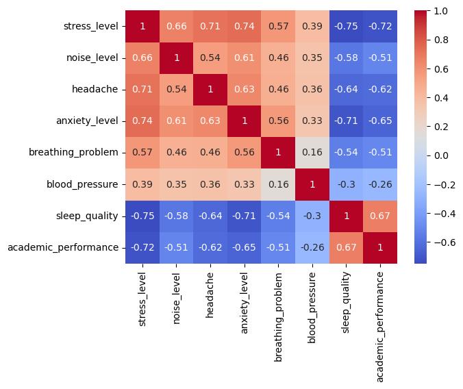

```python
correlation_matrix = df[['stress_level', 'noise_level', 'headache', 'anxiety_level', 'breathing_problem', 'blood_pressure', 'sleep_quality', 'academic_performance']].corr()
sns.heatmap(correlation_matrix, annot=True, cmap='coolwarm')
plt.show()
```

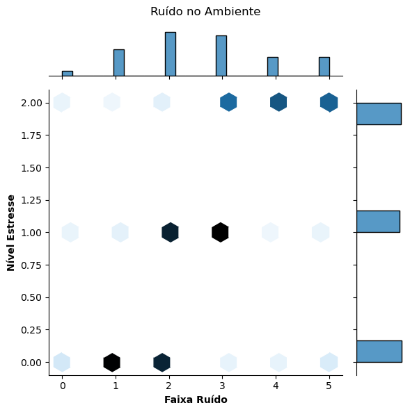

```python
p = sns.jointplot(x='noise_level',y='stress_level',data=df,kind='hex')
p.fig.suptitle("Ruído no Ambiente")
p.ax_joint.set_xlabel('Faixa Ruído', fontweight='bold')
p.ax_joint.set_ylabel('Nível Estresse', fontweight='bold')
p.fig.tight_layout()
```

[figure not shown]

```python
p = sns.jointplot(x='stress_level',y='headache',data=df,kind='hex')
p.fig.suptitle("")
p.ax_joint.set_xlabel('Nível Estresse', fontweight='bold')
p.ax_joint.set_ylabel('Frequência Dor de Cabeça', fontweight='bold')
p.fig.tight_layout()
```

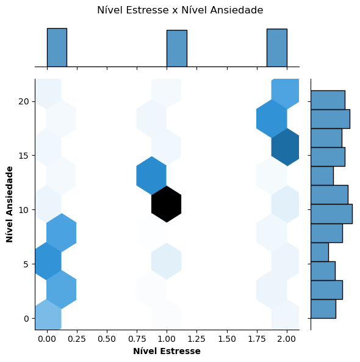

```python
p = sns.jointplot(x='stress_level',y='anxiety_level',data=df,kind='hex')
p.fig.suptitle("Nível Estresse x Nível Ansiedade")
p.ax_joint.set_xlabel('Nível Estresse', fontweight='bold')
p.ax_joint.set_ylabel('Nível Ansiedade', fontweight='bold')
p.fig.tight_layout()
```

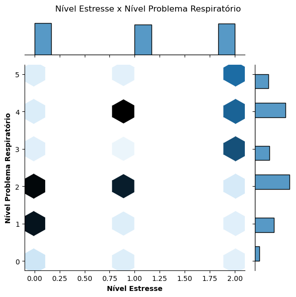

```python
p = sns.jointplot(x='stress_level',y='breathing_problem',data=df,kind='hex')
p.fig.suptitle("Nível Estresse x Nível Problema Respiratório")
p.ax_joint.set_xlabel('Nível Estresse', fontweight='bold')
p.ax_joint.set_ylabel('Nível Problema Respiratório', fontweight='bold')
p.fig.tight_layout()
```

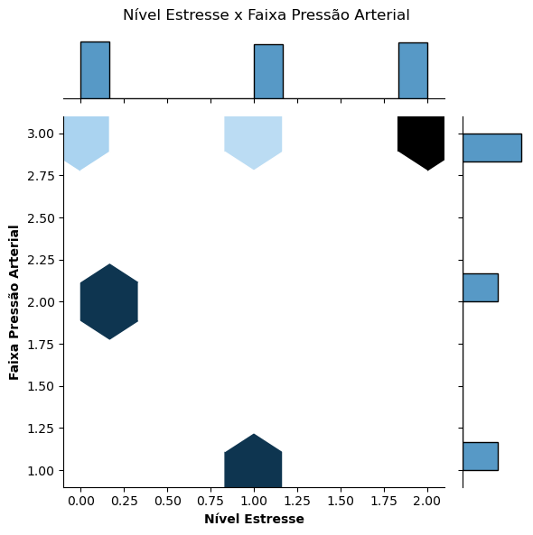

```python
p = sns.jointplot(x='stress_level',y='blood_pressure',data=df,kind='hex')
p.fig.suptitle("Nível Estresse x Faixa Pressão Arterial")
p.ax_joint.set_xlabel('Nível Estresse', fontweight='bold')
p.ax_joint.set_ylabel('Faixa Pressão Arterial', fontweight='bold')
p.fig.tight_layout()
```

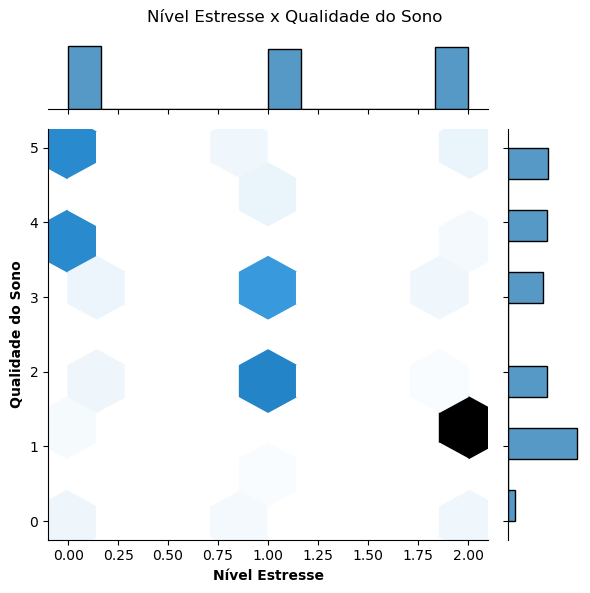

```python
p = sns.jointplot(x='stress_level',y='sleep_quality',data=df,kind='hex')
p.fig.suptitle("Nível Estresse x Qualidade do Sono")
p.ax_joint.set_xlabel('Nível Estresse', fontweight='bold')
p.ax_joint.set_ylabel('Qualidade do Sono', fontweight='bold')
p.fig.tight_layout()
```

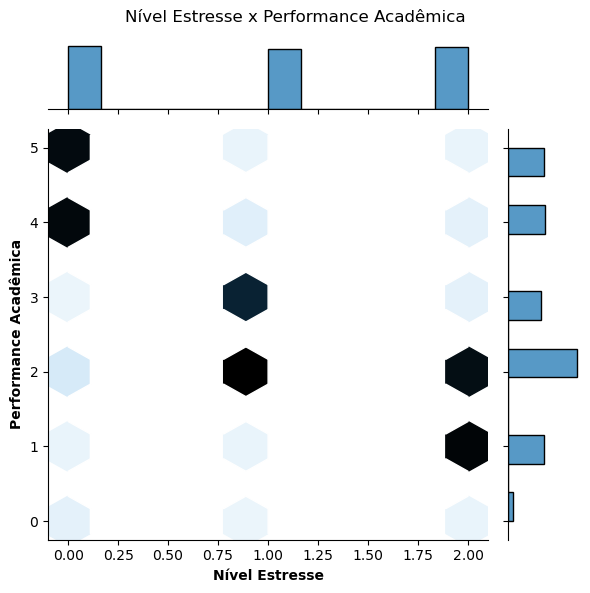

```python
p = sns.jointplot(x='stress_level',y='academic_performance',data=df,kind='hex')
p.fig.suptitle("Nível Estresse x Performance Acadêmica")
p.ax_joint.set_xlabel('Nível Estresse', fontweight='bold')
p.ax_joint.set_ylabel('Performance Acadêmica', fontweight='bold')
p.fig.tight_layout()
```